# Untitled

Brian Boughton

2023-04-28

# Milestone 6 - Hierarchical Clustering

## Goal

### Requirements

- Implement Hierarchical Clustering model
- Display and summarize findings.

This model is going to be done a bit differently than previous models. I will be making clusters based on the month instead of the count of bikes. I am also going to be using casual and registered instead of the cnt total.

### Scenario

The bike rental company wants to find which months to do a discount promotion

## Data Wrangling

The data set is going to have to be turned into a data set with 12 entries and 11 features. The 12 entries will be one for each month and the features will be either the percentage or average of that features for each month.

### Reimportation

The data set will be imported again and this time I will be removing the instant, dteday,cnt,yr,season, and weekday features. This is because each one of them have a direct relation with the date and would be meaningless. Heavy rain will be merged into rain due to it making up such a small part of the data. I will also have to normalize the **casual** and **registered** users features for the clustering to properly be done. I will simply divide each value by the maximum value of the feature.

```r
pj<-read.csv("day.csv")
pj<-subset(pj, select = -c(instant, dteday, cnt,yr, season,weekday))
pj$weathersit<-ifelse(pj$weathersit == 4,3,pj$weathersit)
pj$casual<-pj$casual/max(pj$casual)
pj$registered<-pj$registered/max(pj$registered)
head(pj)
```

```
##   mnth holiday workingday weathersit     temp    atemp      hum windspeed
## 1    1       0          0          2 0.344167 0.363625 0.805833 0.1604460
## 2    1       0          0          2 0.363478 0.353739 0.696087 0.2485390
## 3    1       0          1          1 0.196364 0.189405 0.437273 0.2483090
## 4    1       0          1          1 0.200000 0.212122 0.590435 0.1602960
## 5    1       0          1          1 0.226957 0.229270 0.436957 0.1869000
## 6    1       0          1          1 0.204348 0.233209 0.518261 0.0895652
##       casual registered
## 1 0.09706745 0.09415491
## 2 0.03841642 0.09645839
## 3 0.03519062 0.17693637
## 4 0.03167155 0.20932911
## 5 0.02404692 0.21854305
## 6 0.02580645 0.21854305
```

### Data Percentages

The following code will be find the percentage of holidays, workingdays, sunnydays, cloudydays, rainydays for each month

```r
#Percentage of days that are holidays for each month
holiday<-c(
sum(pj$holiday == 1 & pj$mnth == 1)/sum(pj$mnth ==1),
sum(pj$holiday == 1 & pj$mnth == 2)/sum(pj$mnth ==2),
sum(pj$holiday == 1 & pj$mnth == 3)/sum(pj$mnth ==3),
sum(pj$holiday == 1 & pj$mnth == 4)/sum(pj$mnth ==4),
sum(pj$holiday == 1 & pj$mnth == 5)/sum(pj$mnth ==5),
sum(pj$holiday == 1 & pj$mnth == 6)/sum(pj$mnth ==6),
sum(pj$holiday == 1 & pj$mnth == 7)/sum(pj$mnth ==7),
sum(pj$holiday == 1 & pj$mnth == 8)/sum(pj$mnth ==8),
sum(pj$holiday == 1 & pj$mnth == 9)/sum(pj$mnth ==9),
sum(pj$holiday == 1 & pj$mnth == 10)/sum(pj$mnth ==10),
sum(pj$holiday == 1 & pj$mnth == 11)/sum(pj$mnth ==11),
sum(pj$holiday == 1 & pj$mnth == 12)/sum(pj$mnth ==12))
#Percentage of days that are work days for each month
workingday<-c(
sum(pj$workingday == 1 & pj$mnth == 1)/sum(pj$mnth ==1),
sum(pj$workingday == 1 & pj$mnth == 2)/sum(pj$mnth ==2),
sum(pj$workingday == 1 & pj$mnth == 3)/sum(pj$mnth ==3),
sum(pj$workingday == 1 & pj$mnth == 4)/sum(pj$mnth ==4),
sum(pj$workingday == 1 & pj$mnth == 5)/sum(pj$mnth ==5),
sum(pj$workingday == 1 & pj$mnth == 6)/sum(pj$mnth ==6),
sum(pj$workingday == 1 & pj$mnth == 7)/sum(pj$mnth ==7),
sum(pj$workingday == 1 & pj$mnth == 8)/sum(pj$mnth ==8),
sum(pj$workingday == 1 & pj$mnth == 9)/sum(pj$mnth ==9),
sum(pj$workingday == 1 & pj$mnth == 10)/sum(pj$mnth ==10),
sum(pj$workingday == 1 & pj$mnth == 11)/sum(pj$mnth ==11),
sum(pj$workingday == 1 & pj$mnth == 12)/sum(pj$mnth ==12))
#percentage of days sunny each month
sunny<-c(
sum(pj$weathersit == 1 & pj$mnth == 1)/sum(pj$mnth ==1),
sum(pj$weathersit == 1 & pj$mnth == 2)/sum(pj$mnth ==2),
sum(pj$weathersit == 1 & pj$mnth == 3)/sum(pj$mnth ==3),
sum(pj$weathersit == 1 & pj$mnth == 4)/sum(pj$mnth ==4),
sum(pj$weathersit == 1 & pj$mnth == 5)/sum(pj$mnth ==5),
sum(pj$weathersit == 1 & pj$mnth == 6)/sum(pj$mnth ==6),
sum(pj$weathersit == 1 & pj$mnth == 7)/sum(pj$mnth ==7),
sum(pj$weathersit == 1 & pj$mnth == 8)/sum(pj$mnth ==8),
sum(pj$weathersit == 1 & pj$mnth == 9)/sum(pj$mnth ==9),
sum(pj$weathersit == 1 & pj$mnth == 10)/sum(pj$mnth ==10),
sum(pj$weathersit == 1 & pj$mnth == 11)/sum(pj$mnth ==11),
sum(pj$weathersit == 1 & pj$mnth == 12)/sum(pj$mnth ==12))
#percentage of days that are cloudy
cloudy<-c(
sum(pj$weathersit == 2 & pj$mnth == 1)/sum(pj$mnth ==1),
sum(pj$weathersit == 2 & pj$mnth == 2)/sum(pj$mnth ==2),
sum(pj$weathersit == 2 & pj$mnth == 3)/sum(pj$mnth ==3),
sum(pj$weathersit == 2 & pj$mnth == 4)/sum(pj$mnth ==4),
sum(pj$weathersit == 2 & pj$mnth == 5)/sum(pj$mnth ==5),
sum(pj$weathersit == 2 & pj$mnth == 6)/sum(pj$mnth ==6),
sum(pj$weathersit == 2 & pj$mnth == 7)/sum(pj$mnth ==7),
sum(pj$weathersit == 2 & pj$mnth == 8)/sum(pj$mnth ==8),
sum(pj$weathersit == 2 & pj$mnth == 9)/sum(pj$mnth ==9),
sum(pj$weathersit == 2 & pj$mnth == 10)/sum(pj$mnth ==10),
sum(pj$weathersit == 2 & pj$mnth == 11)/sum(pj$mnth ==11),
sum(pj$weathersit == 2 & pj$mnth == 12)/sum(pj$mnth ==12)
)
#percentage of days that are rainy
rainy<-c(
sum(pj$weathersit == 3 & pj$mnth == 1)/sum(pj$mnth ==1),
sum(pj$weathersit == 3 & pj$mnth == 2)/sum(pj$mnth ==2),
sum(pj$weathersit == 3 & pj$mnth == 3)/sum(pj$mnth ==3),
sum(pj$weathersit == 3 & pj$mnth == 4)/sum(pj$mnth ==4),
sum(pj$weathersit == 3 & pj$mnth == 5)/sum(pj$mnth ==5),
sum(pj$weathersit == 3 & pj$mnth == 6)/sum(pj$mnth ==6),
sum(pj$weathersit == 3 & pj$mnth == 7)/sum(pj$mnth ==7),
sum(pj$weathersit == 3 & pj$mnth == 8)/sum(pj$mnth ==8),
sum(pj$weathersit == 3 & pj$mnth == 9)/sum(pj$mnth ==9),
sum(pj$weathersit == 3 & pj$mnth == 10)/sum(pj$mnth ==10),
sum(pj$weathersit == 3 & pj$mnth == 11)/sum(pj$mnth ==11),
sum(pj$weathersit == 3 & pj$mnth == 12)/sum(pj$mnth ==12))
```

The following code will find the average temp, atemp, hum, wind speed, casual, and registered values for each month.

```r
#Average temp for each month
temp<-c(
mean(pj[pj$mnth == 1, 'temp'], na.rm = TRUE),
mean(pj[pj$mnth == 2, 'temp'], na.rm = TRUE),
mean(pj[pj$mnth == 3, 'temp'], na.rm = TRUE),
mean(pj[pj$mnth == 4, 'temp'], na.rm = TRUE),
mean(pj[pj$mnth == 5, 'temp'], na.rm = TRUE),
mean(pj[pj$mnth == 6, 'temp'], na.rm = TRUE),
mean(pj[pj$mnth == 7, 'temp'], na.rm = TRUE),
mean(pj[pj$mnth == 8, 'temp'], na.rm = TRUE),
mean(pj[pj$mnth == 9, 'temp'], na.rm = TRUE),
mean(pj[pj$mnth == 10, 'temp'], na.rm = TRUE),
mean(pj[pj$mnth == 11, 'temp'], na.rm = TRUE),
mean(pj[pj$mnth == 12, 'temp'], na.rm = TRUE))
#Average atemp for each month
atemp<-c(
mean(pj[pj$mnth == 1, 'atemp'], na.rm = TRUE),
mean(pj[pj$mnth == 2, 'atemp'], na.rm = TRUE),
mean(pj[pj$mnth == 3, 'atemp'], na.rm = TRUE),
mean(pj[pj$mnth == 4, 'atemp'], na.rm = TRUE),
mean(pj[pj$mnth == 5, 'atemp'], na.rm = TRUE),
mean(pj[pj$mnth == 6, 'atemp'], na.rm = TRUE),
mean(pj[pj$mnth == 7, 'atemp'], na.rm = TRUE),
mean(pj[pj$mnth == 8, 'atemp'], na.rm = TRUE),
mean(pj[pj$mnth == 9, 'atemp'], na.rm = TRUE),
mean(pj[pj$mnth == 10, 'atemp'], na.rm = TRUE),
mean(pj[pj$mnth == 11, 'atemp'], na.rm = TRUE),
mean(pj[pj$mnth == 12, 'atemp'], na.rm = TRUE))
#Average humidity for each month
hum<-c(
mean(pj[pj$mnth == 1, 'hum'], na.rm = TRUE),
mean(pj[pj$mnth == 2, 'hum'], na.rm = TRUE),
mean(pj[pj$mnth == 3, 'hum'], na.rm = TRUE),
mean(pj[pj$mnth == 4, 'hum'], na.rm = TRUE),
mean(pj[pj$mnth == 5, 'hum'], na.rm = TRUE),
mean(pj[pj$mnth == 6, 'hum'], na.rm = TRUE),
mean(pj[pj$mnth == 7, 'hum'], na.rm = TRUE),
mean(pj[pj$mnth == 8, 'hum'], na.rm = TRUE),
mean(pj[pj$mnth == 9, 'hum'], na.rm = TRUE),
mean(pj[pj$mnth == 10, 'hum'], na.rm = TRUE),
mean(pj[pj$mnth == 11, 'hum'], na.rm = TRUE),
mean(pj[pj$mnth == 12, 'hum'], na.rm = TRUE))
#Average wind speed for each month
windspeed<-c(
mean(pj[pj$mnth == 1, 'windspeed'], na.rm = TRUE),
mean(pj[pj$mnth == 2, 'windspeed'], na.rm = TRUE),
mean(pj[pj$mnth == 3, 'windspeed'], na.rm = TRUE),
mean(pj[pj$mnth == 4, 'windspeed'], na.rm = TRUE),
mean(pj[pj$mnth == 5, 'windspeed'], na.rm = TRUE),
mean(pj[pj$mnth == 6, 'windspeed'], na.rm = TRUE),
mean(pj[pj$mnth == 7, 'windspeed'], na.rm = TRUE),
mean(pj[pj$mnth == 8, 'windspeed'], na.rm = TRUE),
mean(pj[pj$mnth == 9, 'windspeed'], na.rm = TRUE),
mean(pj[pj$mnth == 10, 'windspeed'], na.rm = TRUE),
mean(pj[pj$mnth == 11, 'windspeed'], na.rm = TRUE),
mean(pj[pj$mnth == 12, 'windspeed'], na.rm = TRUE))
#Average casual rider per month
casual<-c(
mean(pj[pj$mnth == 1, 'casual'], na.rm = TRUE),
mean(pj[pj$mnth == 2, 'casual'], na.rm = TRUE),
mean(pj[pj$mnth == 3, 'casual'], na.rm = TRUE),
mean(pj[pj$mnth == 4, 'casual'], na.rm = TRUE),
mean(pj[pj$mnth == 5, 'casual'], na.rm = TRUE),
mean(pj[pj$mnth == 6, 'casual'], na.rm = TRUE),
mean(pj[pj$mnth == 7, 'casual'], na.rm = TRUE),
mean(pj[pj$mnth == 8, 'casual'], na.rm = TRUE),
mean(pj[pj$mnth == 9, 'casual'], na.rm = TRUE),
mean(pj[pj$mnth == 10, 'casual'], na.rm = TRUE),
mean(pj[pj$mnth == 11, 'casual'], na.rm = TRUE),
mean(pj[pj$mnth == 12, 'casual'], na.rm = TRUE))
#Average Registered rider per month
registered<-c(
mean(pj[pj$mnth == 1, 'registered'], na.rm = TRUE),
mean(pj[pj$mnth == 2, 'registered'], na.rm = TRUE),
mean(pj[pj$mnth == 3, 'registered'], na.rm = TRUE),
mean(pj[pj$mnth == 4, 'registered'], na.rm = TRUE),
mean(pj[pj$mnth == 5, 'registered'], na.rm = TRUE),
mean(pj[pj$mnth == 6, 'registered'], na.rm = TRUE),
mean(pj[pj$mnth == 7, 'registered'], na.rm = TRUE),
mean(pj[pj$mnth == 8, 'registered'], na.rm = TRUE),
mean(pj[pj$mnth == 9, 'registered'], na.rm = TRUE),
mean(pj[pj$mnth == 10, 'registered'], na.rm = TRUE),
mean(pj[pj$mnth == 11, 'registered'], na.rm = TRUE),
mean(pj[pj$mnth == 12, 'registered'], na.rm = TRUE))
```

### Creating Dataframe

Now that all the needed information has been extracted from the raw dataset, I can merge it all together into on new dataset called **df**. The column names will be the names of the values I extracted and the row names will be the months of the year.

```r
df<-as.data.frame(cbind(workingday,holiday,sunny,cloudy,rainy,temp,atemp,hum,windspeed,casual,registered))
rownames(df)<-c('Jan','Feb','Mar','Apr','May','Jun','Jul','Aug','Sep','Oct','Nov','Dec')
df
```

```
##     workingday    holiday     sunny    cloudy      rainy      temp     atemp
## Jan  0.6451613 0.04838710 0.5967742 0.3870968 0.01612903 0.2364439 0.2397959
## Feb  0.6842105 0.03508772 0.6491228 0.3333333 0.01754386 0.2992264 0.2997313
## Mar  0.7258065 0.00000000 0.5806452 0.3870968 0.03225806 0.3905388 0.3819537
## Apr  0.6666667 0.03333333 0.6166667 0.3500000 0.03333333 0.4699988 0.4570809
## May  0.6935484 0.03225806 0.5967742 0.4032258 0.00000000 0.5947984 0.5656620
## Jun  0.7166667 0.00000000 0.7666667 0.2333333 0.00000000 0.6840972 0.6382457
## Jul  0.6612903 0.03225806 0.8225806 0.1612903 0.01612903 0.7554704 0.7040939
## Aug  0.7419355 0.00000000 0.6935484 0.3064516 0.00000000 0.7085816 0.6514748
## Sep  0.6666667 0.03333333 0.5500000 0.4000000 0.05000000 0.6164850 0.5792991
## Oct  0.6774194 0.03225806 0.5161290 0.4032258 0.08064516 0.4850122 0.4719732
## Nov  0.6666667 0.06666667 0.7000000 0.2500000 0.05000000 0.3692198 0.3673588
## Dec  0.6612903 0.03225806 0.5161290 0.4354839 0.04838710 0.3240310 0.3261597
##           hum windspeed     casual registered
## Jan 0.5858283 0.2063028 0.05695771  0.2853603
## Feb 0.5674647 0.2156839 0.07698204  0.3444845
## Mar 0.5884750 0.2226994 0.21021663  0.4283644
## Apr 0.5880631 0.2344822 0.29717498  0.4997888
## May 0.6889583 0.1829889 0.35609214  0.5953786
## Jun 0.5758055 0.1854199 0.36122190  0.6537000
## Jul 0.5978763 0.1660588 0.36967647  0.6195048
## Aug 0.6377301 0.1729181 0.34073881  0.6482148
## Sep 0.7147144 0.1659451 0.34370968  0.6614550
## Oct 0.6937609 0.1752055 0.28266011  0.6097545
## Nov 0.6248765 0.1838014 0.17890029  0.5236299
## Dec 0.6660405 0.1766089 0.10260619  0.4396659
```

Now, we have a 12X11 table with each value in a range of 0-1. This will allow for the euclidean distance formulas to be done properly.

## Building the model

### Euclidean Distance Matrix

Below is a matrix displaying the euclidean distances between each month. These numbers will be used when developing the Hierarchical clusters.

```r
(dist<-dist(df[1:11], method = "euclidean"))
```

```
##           Jan       Feb       Mar       Apr       May       Jun       Jul
## Feb 0.1385293
## Mar 0.3123037 0.2261283
## Apr 0.4571659 0.3594378 0.1790076
## May 0.6591665 0.5681463 0.3741123 0.2405586
## Jun 0.8050864 0.6830215 0.5351284 0.3870919 0.2979627
## Jul 0.8936827 0.7723880 0.6459044 0.4951907 0.4063866 0.1556172
## Aug 0.7976418 0.6837020 0.5144111 0.3749541 0.2194902 0.1286319 0.2319264
## Sep 0.7111951 0.6246723 0.4328221 0.3043961 0.1074782 0.3300321 0.4282940
## Oct 0.5447100 0.4701624 0.2804739 0.2067173 0.1994508 0.4360269 0.5484888
## Nov 0.3727870 0.2610688 0.2342215 0.2345653 0.4115850 0.4891464 0.5783312
## Dec 0.2423752 0.2277731 0.1983719 0.3271399 0.4802812 0.6767868 0.7794458
##           Aug       Sep       Oct       Nov
## Feb
## Mar
## Apr
## May
## Jun
## Jul
## Aug
## Sep 0.2418355
## Oct 0.3778234 0.1947878
## Nov 0.5037096 0.4546619 0.3269250
## Dec 0.6424457 0.5117148 0.3341224 0.2962847
```

### Developing Hierarachical Models

We will compare the five different options to see if it divides our data into different clusters while using k=4.

```r
hc1 <- hclust(dist, method = "single")
(memb1<-cutree(hc1, k=4))
```

```
## Jan Feb Mar Apr May Jun Jul Aug Sep Oct Nov Dec
##   1   1   2   2   2   3   3   3   2   2   4   2
```

```r
hc2 <- hclust(dist, method = "average")
(memb2<-cutree(hc2, k=4))
```

```
## Jan Feb Mar Apr May Jun Jul Aug Sep Oct Nov Dec
##   1   1   2   2   3   4   4   4   3   3   2   1
```

```r
hc3 <- hclust(dist, method = "complete")
(memb3<-cutree(hc3, k=4))
```

```
## Jan Feb Mar Apr May Jun Jul Aug Sep Oct Nov Dec
##   1   1   2   2   3   4   4   4   3   3   2   1
```

```r
hc4 <- hclust(dist, method = "median")
(memb4<-cutree(hc4, k=4))
```

```
## Jan Feb Mar Apr May Jun Jul Aug Sep Oct Nov Dec
##   1   1   2   2   3   4   4   4   3   3   2   1
```

```r
hc5 <- hclust(dist, method = "centroid")
(memb5<-cutree(hc5, k=4))
```

```
## Jan Feb Mar Apr May Jun Jul Aug Sep Oct Nov Dec
##   1   1   2   2   3   4   4   4   3   3   2   1
```

## Evaluation

### Hierarachial plot

The complete linkage method produced the most visually useful chart so I have generated a plot of the tree below.

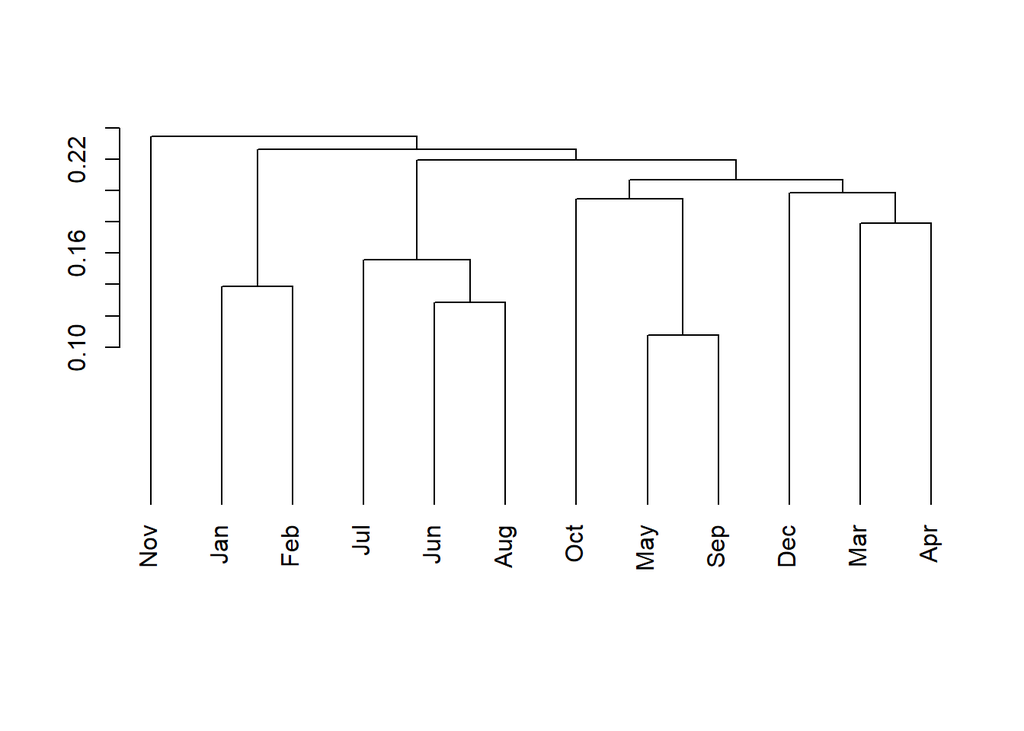

```r
#Sinlge Linkage
plot(hc1, hang = -1, ann = FALSE,)
```

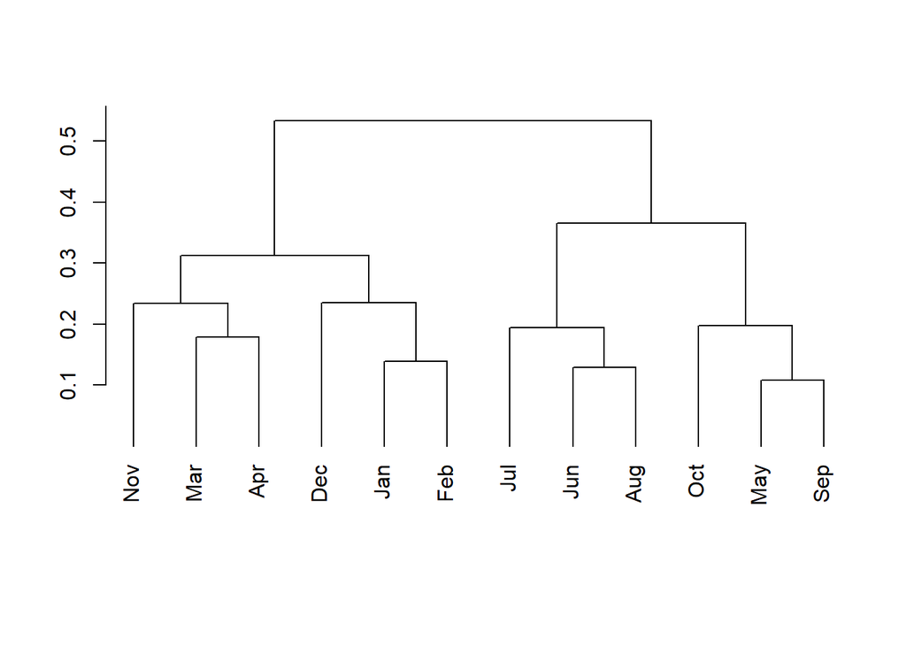

```r
plot(hc2, hang = -1, ann = FALSE)
```

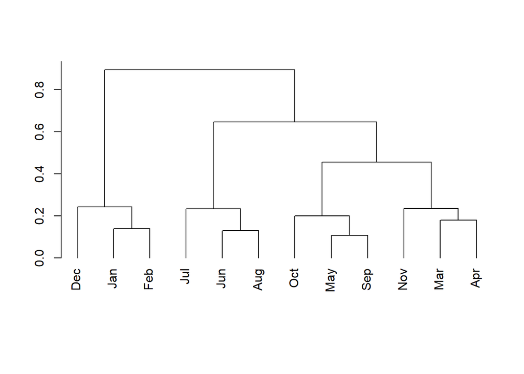

```r
plot(hc3, hang = -1, ann = FALSE)
```

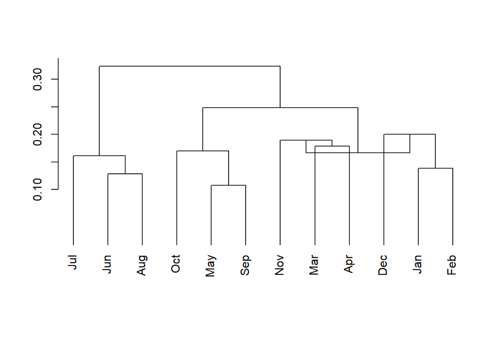

```r
plot(hc4, hang = -1, ann = FALSE)
```

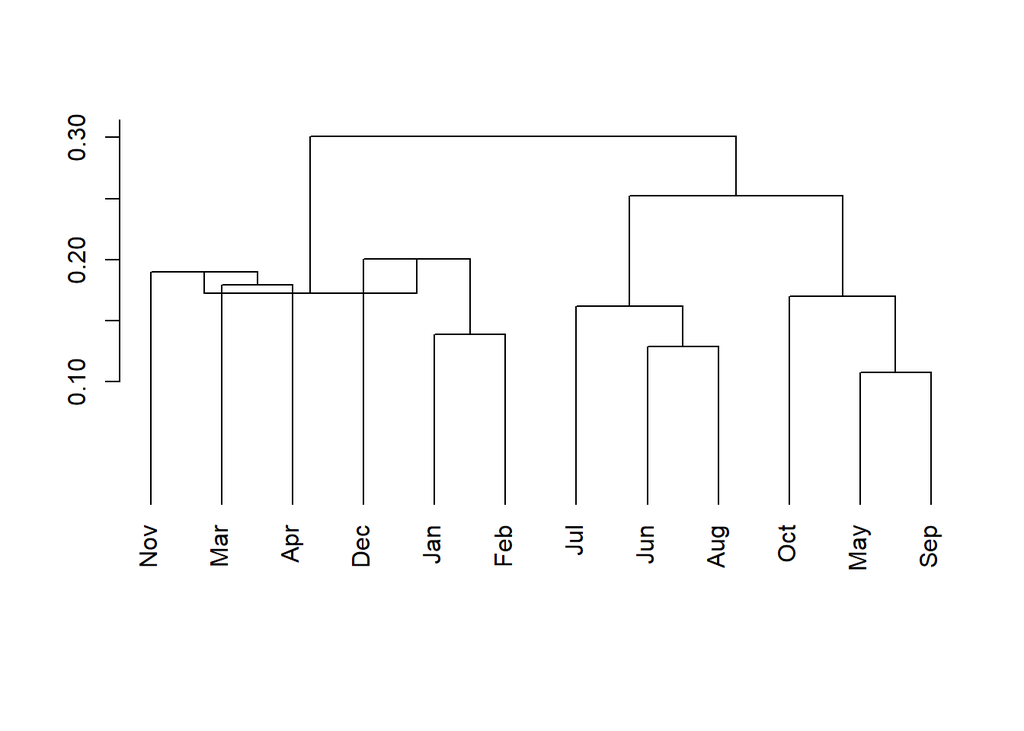

```r
plot(hc5, hang = -1, ann = FALSE)
```

### Heatmap

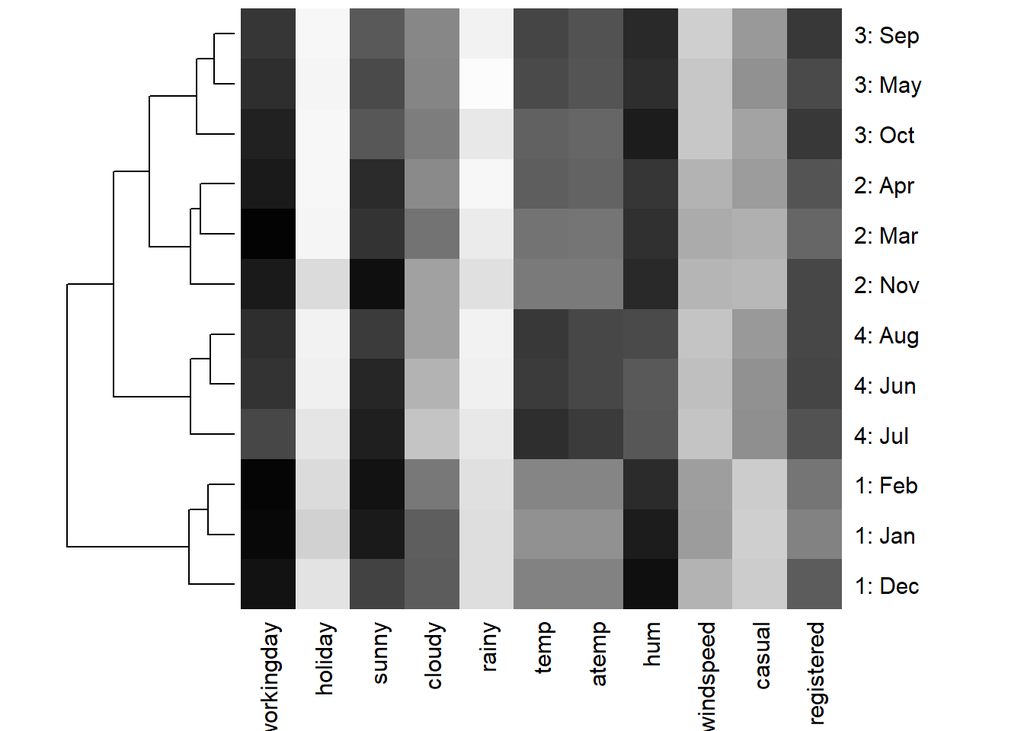

```r
df1<-df
row.names(df1) <- paste(memb3, ": ", row.names(df1), sep = "")
heatmap(as.matrix(df1), Colv = NA, hclustfun = hclust, col=rev(paste("gray",1:99,sep="")))
```